# targets Pipeline Documentation

Technical Design Document

Published

September 18, 2026

# targets Pipeline Documentation

This document describes the `targets` pipeline for the IPBES BM Fact Checker project.

**Note: this document predates the reporting/explorer layer and is stale in that respect** — it does not describe the `nli_ready_evidence_parquet` → `nli_claim_units_evidence` → `nli_scores_by_claim_evidence` chain, or the downstream `nli_overview_data`, `nli_overview_figures`, `nli_bm_explorer_html`, `reports_project`, and `report_fact_checker` targets, all of which exist and run today. See `_targets.R` and CLAUDE.md’s R-files table for the current, authoritative target list.

## Overview

The pipeline fetches IPBES assessment data from the [IPBES Linked Open Data (LOD)](https://github.com/IPBES-Data/IPBES_LOD) repository in RDF/Turtle format, queries the assessments via SPARQL, and produces per-assessment Parquet datasets for refs, sections, key-messages, Zotero items, OpenAlex works, snowball results, and NLI alignment scores.

The **active scoring approach** is NLI (`nli_scores_by_claim` / `nli_scores_by_claim_evidence`): each citing work is classified as SUPPORTS / REFUTES / NOT_ENOUGH_INFO against its partition’s Background Message using a zero-shot `bge-m3-zeroshot-v2.0-c` NLI model served on RunPod (see external/runpod/docker/nli-runpod/ and TD_BM_NLI_approach.qmd) — `deberta-v3-large-zeroshot-v2.0` was the original model, now retired.

**Phase 2 LLM verification** (`llm_verification_parquet`) reviews whichever slice of NLI scores each config’s `nli_labels`/`nli_certainty` fields select (currently `REFUTES` + `SUPPORTS`, both `certain`, on every shipped config — ~79k of 3.5M scored pairs), one `ellmer::chat_openrouter()` call per `(claim, work)` pair — every routed pair is reviewed, none filtered, but each is tagged `direct_evidence_match` by `llm_candidate_scope_parquet` (via IPBES’s own sub-chapter evidence references; a former `subset: "default"` candidate-narrowing filter was retired here since it only reduced routed pairs by ~14%, not worth the lost review coverage) — see TD_NLI_LLM_two_phase.qmd for the design and R/build_llm_verification_parquet.R/R/build_llm_candidate_scope_parquet.R for the implementation. The earlier truth/citing-document LLM design it replaced (`prompts_truth_parquet` → `prompts_citing_parquet` → `alignement_scores_parquet`) has been removed; see TD_LLM_approach.qmd for that record.

Fuseki startup and shutdown are handled inside the parquet builders rather than as separate targets. When `sparql_url: fuseki`, each builder boots an in-memory Fuseki, POSTs the TTL into the named graph `http://ontology.ipbes.net/report/<id>` via the Graph Store Protocol, runs its query, and tears Fuseki down.

## Running the Pipeline

The work is split across **four** `targets` projects, declared in `_targets.yaml`. Each has its own script and its own store, so rendering a report cannot reach a target that spends GPU time or API credit — a guarantee that used to rest on remembering `shortcut = TRUE`.

| Project | Script / store | Holds | Credentials |
| --- | --- | --- | --- |
| `main` | `_targets.R` / `_targets/` | collection: LOD → refs → zotero → works → snowball → works_citing | `API_openalex` |
| `factcheck` | `_targets_factcheck.R` / `_targets_factcheck/` | citing works → NLI (Phase 1) → LLM verification (Phase 2) | `API_openrouter` |
| `training` | `_targets_training.R` / `_targets_training/` | key papers → NLI → LLM → training set → fine-tune | `API_openrouter` |
| `reporting` | `_targets_reporting.R` / `_targets_reporting/` | everything that renders | **none** |

```r
# The default project is `main` (collection)
targets::tar_make()

# Pick another project for the session...
Sys.setenv(TAR_PROJECT = "factcheck")
targets::tar_make()

# ...or address one directly
targets::tar_make(script = "_targets_reporting.R", store = "_targets_reporting")

# Visualise the dependency graph of the current project
targets::tar_visnetwork()

# Check which targets are outdated
targets::tar_outdated()

# Load a target into your session
targets::tar_load(refs_parquet)
```

`main` deliberately keeps the **original** `_targets/` store. A fresh store would make every target outdated by definition, and `download_works()` `unlink()`s its output before refetching while `build_snowball_parquet()` has no existence check at all — re-running them would cost days of OpenAlex time *and* produce a different corpus from the one every existing score was computed against. Targets were therefore *deleted from* `_targets.R` as they moved out.

Each consumer declares the upstream outputs it reads as `format = "file"` targets **keeping the producing project’s target names**, so the moved targets work verbatim and a genuine upstream change still invalidates downstream through content hashing. See `TODO_PIPELINE_SPLIT.md` for the full design.

## Pipeline Diagrams

### Rendered Workflow (NLI approach)

Hand-authored, and split per project along the same boundaries as the pipeline diagrams below.

#### `main` — collection

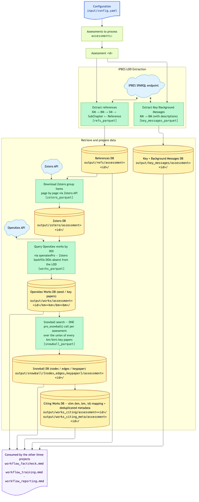

Workflow: main

#### `factcheck` — citing works → NLI → LLM verification

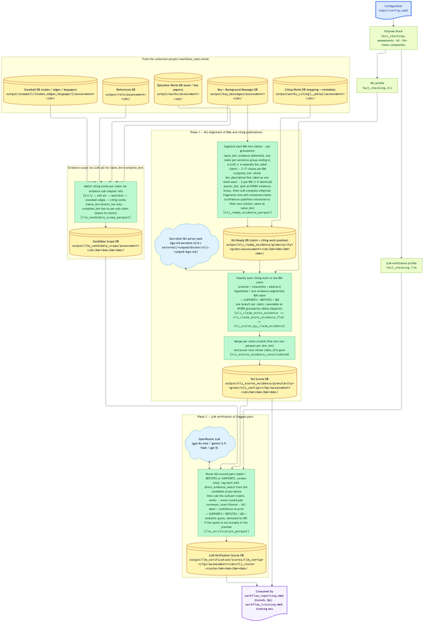

Workflow: factcheck

#### `training` — key papers → NLI → LLM → training set → fine-tune

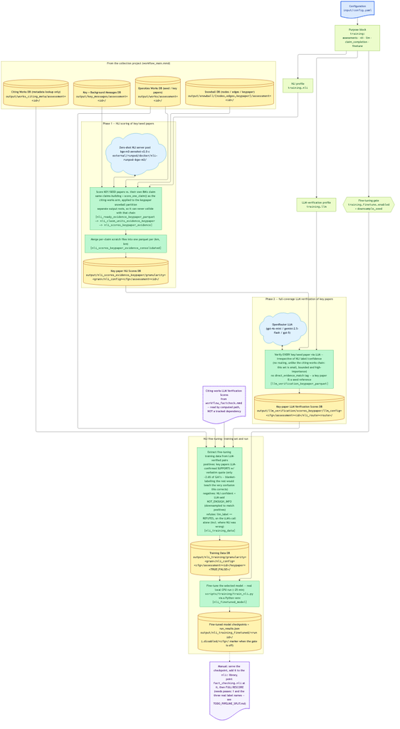

Workflow: training

#### `reporting`

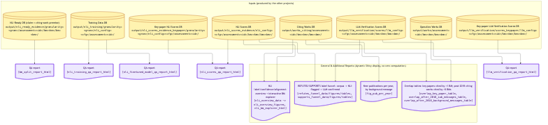

Workflow: reporting

### Pipeline

Auto-generated from the live `targets` DAG. Since the pipeline was split into separate projects (see `TODO_PIPELINE_SPLIT.md` and `_targets.yaml`), there is no longer a single DAG to draw, so each project renders its own: `build_pipeline_mmd()` depicts whatever graph it is run inside. These can be combined into one overview later.

#### `main` — collection (`_targets.R`)

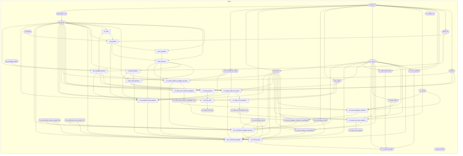

Pipeline: main

#### `factcheck` (`_targets_factcheck.R`)

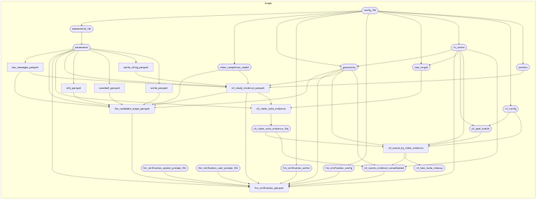

Pipeline: factcheck

#### `training` (`_targets_training.R`)

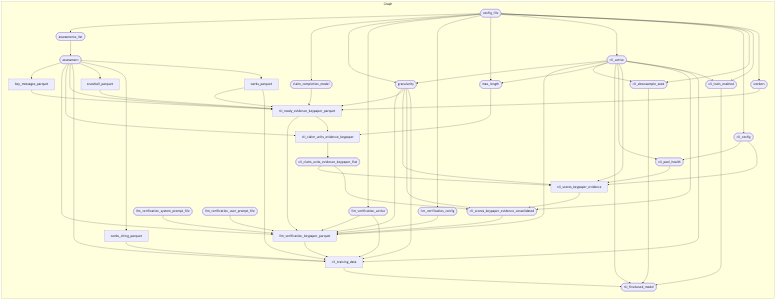

Pipeline: training

#### `reporting` (`_targets_reporting.R`)

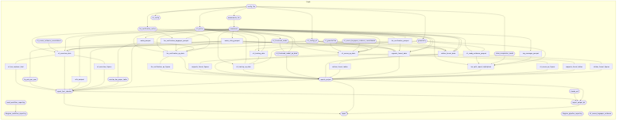

Pipeline: reporting

## Pipeline DAG

This is the **logical** dependency chain end to end, as it was before the split and as it still is in substance — it now spans four projects rather than one, with each consumer re-declaring the upstream outputs it reads as `format = "file"` inputs under the producing project’s own target names. The per-project pictures above show where the cuts fall.

```
config_file (file)
    ├── sparql_url                              ← SPARQL backend string
    ├── purpose                                 ← this project's block (fact_checking: / training:)
    ├── nli_active                              ← selected NLI profile name
    ├── nli_config                              ← resolved NLI profile (host, model, etc.)
    ├── assessments_list
    │       └── assessment (list, branched)
    │               ├── ttl_path (file)                    ← Target 1
    │               ├── refs_sparql (file) ──────────────── queries/refs.sparql
    │               ├── refs_parquet (file)                ← Target 2a
    │               ├── key_messages_sparql (file) ──────── queries/key_messages.sparql
    │               ├── key_messages_parquet (file)        ← Target 2b2
    │               ├── zotero_parquet (file)              ← Target 2c
    │               ├── works_parquet (file)               ← Target 2d
    │               ├── snowball_parquet (file)            ← Target 2e
    │               └── works_citing_parquet (file)        ← Target 2f
    └── nli_config ─────────────────────────────────────────┐
        assessment ─────────────────────────────────────────┤
        key_messages_parquet ───────────────────────────────┤→ nli_scores_parquet ← Target 2g
        works_citing_parquet ───────────────────────────────┘
```

**Phase 2 — LLM verification + candidate scoping** (both active targets):

```
assessment ───────────────────────────────────┐
key_messages_parquet ─────────────────────────┤
refs_parquet ──────────────────────────────────┤→ llm_candidate_scope_parquet ← Target 2h4a
works_parquet ─────────────────────────────────┤
snowball_parquet ──────────────────────────────┤
nli_ready_evidence_parquet ────────────────────┘

nli_active ──────────────────────────────────┐
assessment ──────────────────────────────────┤
nli_ready_evidence_parquet ──────────────────┤
llm_verification_active ─────────────────────┤→ llm_verification_parquet ← Target 2h4b
llm_verification_config ─────────────────────┤
llm_verification_system_prompt_file ─────────┤
llm_verification_user_prompt_file ───────────┤
llm_candidate_scope_parquet ──────────────────┤
nli_scores_by_claim_evidence (DAG dep only) ──┘

config_file ── llm_verification_active ── llm_verification_config   (mirrors nli_active → nli_config)
```

`llm_candidate_scope_parquet` reads only already-existing, unmodified targets (`key_messages_parquet`, `refs_parquet`, `works_parquet`, `snowball_parquet`, `claim_completion_model`, plus `nli_ready_evidence_parquet` for a drift sanity check) — adding it does not invalidate Phase 1’s NLI chain or any download/snowball step upstream of it. Under `naive_bm`/`complete_bm` it makes no network/API calls of its own; under `atomic_bm` it re-runs `complete_bm_fragments()` (normally a cache-hit against the completion cache a real atomic_bm `nli_ready_evidence_parquet` build already populated) to recover claim alignment. It always runs regardless of which `llm_verification` config is active, since every config’s output now carries the `direct_evidence_match` tag it produces.

## Configuration (`input/config.yaml`)

```yaml
sparql_url: fuseki

assessments:
  - id: GA1
    ttl_url: https://...
  - id: IAS
    ttl_url: https://...

# `nli:` and `llm_verification:` are LIBRARIES of named definitions. They
# select nothing themselves -- see the purpose blocks below.
nli:
  configs:
    bge_m3_zeroshot_naive_bm:
      scheme: https
      host: ["<pod-id-1>-8080.proxy.runpod.net", "<pod-id-2>-8080.proxy.runpod.net"]
      port: null
      model: MoritzLaurer/bge-m3-zeroshot-v2.0-c   # deberta-v3-large-zeroshot-v2.0 was the original model, now retired
      candidate_labels: ["supports", "refutes", "is not relevant to"]
      hypothesis_template: "This paper {} the following claim: %s"
      batch_size: 64
      max_length: 2048
      uncertain_threshold: 0.60
      nei_threshold: 0.90
      granularity: naive_bm   # complete_bm / atomic_bm also supported

# Purpose blocks: scope + selection, one per consuming project.
fact_checking:
  assessments: [GA1]
  nli: bge_m3_zeroshot_atomic_bm
  llm: openrouter_cheap
  claim_completion: haiku_completion

training:
  assessments: [GA1, VA, TCA, IAS, BBA]
  nli: bge_m3_zeroshot_atomic_bm
  llm: openrouter_cheap
  claim_completion: haiku_completion
  finetune:
    enabled: true
    downsample_seed: 13
```

There is no global `active:` any more. It was a single answer to a question each project answers for itself: fact checking is scoped to one assessment because it is the expensive arm, training pools all five key-paper sets, and the two need not agree on a model. While there was one DAG the conflation was invisible; with four projects it is wrong.

Selections are resolved and **validated** by `purpose_config()` (R/branch_helpers.R) — naming a config that is not in the corresponding library is a hard error, because it would otherwise read as “nothing has been scored yet” and re-dispatch a corpus at real GPU cost.

Scope lives in the purpose block rather than as per-assessment flags inside `assessments:`. Flags there would change `assessments_list`’s value and so invalidate `assessment`, `ttl_path`, `works_parquet`, `snowball_parquet` and everything downstream; `purpose_assessments_list()` preserves the exact element shape `assessments_list` has always produced, so a purpose listing every assessment yields a byte-identical value.

`train:`/`downsample_seed:` also moved out of the serving configs into `training.finetune`, where they belong — how a model is *served* and whether the training project *trains* one are different questions.

Config is split into fine-grained targets — each reads only its own section from `config_file` directly (no intermediate `config` target). Changing one section re-runs only that target; if the extracted value is unchanged, nothing downstream cascades.

| Config key | Target | Invalidates |
| --- | --- | --- |
| `sparql_url` | `sparql_url` | All SPARQL build targets |
| `assessments` | `assessments_list` → `assessment` | Assessment branches and their outputs |
| `fact_checking.*` / `training.*` | `purpose` (per project) → `nli_active`, `llm_verification_active`, `claim_completion_model`, `assessments_list` | that project’s chain only |
| `nli.configs.<selected>.*` | `nli_config` | the NLI scoring chain of whichever project selected it |
| `llm_verification.configs.<selected>.*` | `llm_verification_config` | that project’s LLM verification target only |

Note `config_file` is a `format = "file"` target over the **whole** YAML, so any edit to it — including swapping a pod hostname — marks it outdated and `tar_outdated()` projects that pessimistically down the chain. It clears itself as soon as the cheap config targets re-run and produce identical values; nothing expensive actually rebuilds.

## Target 0: `assessment` — Assessment Specs

**Source:** `_targets.R`

Creates a named list of assessment specifications from `assessments_list`. Each element gains an `index` field used for deterministic Fuseki port assignment. Branch names are the assessment IDs — adding a new assessment creates a new branch without invalidating existing ones.

## Target 1: `ttl_path` — Download TTL File

**Source:** `R/download_ttls.R` → `download_ttl(assessment)`

For each assessment branch: 1. Creates `output/LoD/` if it does not exist. 2. Queries the GitHub Contents API for the current SHA of the remote TTL file. 3. Skips the download if a local copy with a matching SHA already exists. 4. Otherwise downloads to `output/LoD/<id>.ttl` and writes the SHA next to it.

Returns a character vector of local TTL file paths (`format = "file"`).

> Even when `sparql_url` is a remote URL, TTL files are still downloaded as a declared pipeline dependency. The download is cheap once cached.

## Target 2a: `refs_parquet` — DB1

**Source:** `R/write_refs_parquet.R` → `build_refs_parquet(sparql_url, assessment, ttl_path, refs_sparql, "output/refs")`

Builds the refs dataset for one assessment branch and writes to `output/refs/assessment=<id>/`. When `sparql_url: fuseki`, starts a local Fuseki session, POSTs the TTL into the named graph, runs the SPARQL query, and stops Fuseki on exit.

### Reading DB1

```r
arrow::open_dataset("output/refs") |>
  dplyr::filter(assessment == "GA1", km == "A.", bm == "A1") |>
  dplyr::collect()
```

### Schema — DB1

| Column | Type | Description |
| --- | --- | --- |
| `assessment` | chr | Assessment ID (partition) |
| `km` | chr | Key Message identifier |
| `bm` | chr | Background Message identifier |
| `sm` | chr | Sub-Message identifier |
| `doi` | chr | DOI string — `NA` if absent |
| `description` | chr | Citation text from the LOD |
| `citation` | chr | Zotero-key citation string like `[P62TQUG2]` |
| `zotero_group` | chr | Zotero group id |
| `zotero_key` | chr | Raw Zotero item key |
| `zotero` | chr | Zotero URL (`owl:sameAs`) |

## Target 2b: `sections_parquet` — DB2

**WarningDisabled 2026-09-15 — no longer part of the pipeline**

`sections_parquet` and `sections_sparql` are commented out in `_targets.R`, and `output/sections/` has been deleted. Nothing consumed the dataset: no target took `sections_parquet` as an argument and no `.qmd` read it — its only ever consumer was `R/resolve_citations.R`, itself long orphaned — so it cost a SPARQL extraction and Fuseki round trip per assessment on every rebuild for output nothing read.

`R/write_sections_parquet.R` and `queries/sections.sparql` both still exist. Re-enabling is uncommenting the block in `_targets.R`. The description below is kept as a record of what it produced.

**Source:** `R/write_sections_parquet.R` → `build_sections_parquet(sparql_url, assessment, ttl_path, sections_sparql, "output/sections")`

Built the sections dataset for one assessment branch. Each SubChapter source row carried the SubMessage that referenced it (`sm` column). Written to `output/sections/assessment=<id>/`.

### Reading DB2

```r
arrow::open_dataset("output/sections") |>
  dplyr::filter(assessment == "GA1", km == "A.", bm == "A1") |>
  dplyr::collect()
```

### Schema — DB2

| Column | Type | Description |
| --- | --- | --- |
| `assessment` | chr | Assessment ID (partition) |
| `km` | chr | Key Message identifier |
| `bm` | chr | Background Message identifier |
| `sm` | chr | Sub-Message identifier |
| `section` | chr | Chapter identifier |
| `subsection` | chr | SubChapter identifier |
| `content` | chr | SubChapter description text |

## Target 2b2: `key_messages_parquet` — DB3

**Source:** `R/write_key_messages_parquet.R` → `build_key_messages_parquet(sparql_url, assessment, ttl_path, key_messages_sparql, "output/key_messages")`

Builds the key/background/sub-messages dataset for one assessment branch. Written to `output/key_messages/assessment=<id>/`.

### Reading DB3

```r
arrow::open_dataset("output/key_messages") |>
  dplyr::filter(assessment == "GA1", km == "A.", bm == "A1") |>
  dplyr::collect()
```

### Schema — DB3

| Column | Type | Description |
| --- | --- | --- |
| `assessment` | chr | Assessment ID (partition) |
| `km` | chr | Key Message identifier |
| `km_label` | chr | KM headline text |
| `km_description` | chr | KM detail text |
| `bm` | chr | Background Message identifier |
| `bm_label` | chr | BM headline text |
| `bm_description` | chr | BM detail text — used as NLI hypothesis |
| `bm_well_established` | chr | BM confidence flag |
| `bm_established_incomplete` | chr | BM confidence flag |
| `sm_id` | chr | Sub-Message identifier |
| `sm_description` | chr | SM statement text |
| `sm_well_established` | chr | SM confidence flag |
| `sm_established_incomplete` | chr | SM confidence flag |

## Target 2c: `zotero_parquet` — Zotero Group Items

**Source:** `R/download_zotero.R` → `download_zotero(assessment, refs_parquet)`

Reads the refs branch for one assessment, infers the Zotero group id from the `zotero` column, downloads all top-level Zotero items page by page, and writes to `output/zotero/assessment=<id>/` partitioned by `group_id` and `page`.

## Target 2d: `works_parquet` — OpenAlex Works

**Source:** `R/download_works.R` → `download_works(assessment, zotero_parquet, refs_parquet, workers = 8)`

Reads DOIs from the Zotero branch, fetches OpenAlex works with `openalexPro::pro_fetch()`, then joins with `refs_parquet` on normalised DOI to attach `km` and `bm` columns. Written to `output/works/assessment=<id>/` partitioned by `assessment`, `km`, and `bm`.

### Reading DB4

```r
arrow::open_dataset("output/works") |>
  dplyr::filter(assessment == "GA1", km == "A.", bm == "A1") |>
  dplyr::select(id, doi, title) |>
  dplyr::collect()
```

### Schema — DB4 (selected columns)

| Column | Type | Description |
| --- | --- | --- |
| `assessment` | chr | Assessment ID (partition) |
| `km` | chr | Key Message identifier (partition) |
| `bm` | chr | Background Message identifier (partition) |
| `id` | chr | OpenAlex work ID URL |
| `doi` | chr | DOI string |
| `title` | chr | Work title |
| `publication_year` | int | Year of publication |
| … | … | 51 OpenAlex columns total |

## Target 2e: `snowball_parquet` — Snowball Search

**Source:** `R/build_snowball_parquet.R` → `build_snowball_parquet(assessment, works_parquet, "output/snowball")`

- `output/snowball/nodes/` — partitioned by `assessment`, `km`, `bm`, `relation`
- `output/snowball/edges/` — partitioned by `assessment`, `km`, `bm`, `edge_type`
- `output/snowball/keypaper/` — partitioned by `assessment`, `km`, `bm`

### Reading

```r
arrow::open_dataset("output/snowball/nodes") |>
  dplyr::filter(assessment == "GA1", km == "A.", bm == "A1") |>
  dplyr::select(id, doi, title, relation) |>
  dplyr::collect()
```

### Schema — Nodes

| Column | Type | Description |
| --- | --- | --- |
| `assessment` | chr | Assessment ID (partition) |
| `km` | chr | Key Message identifier (partition) |
| `bm` | chr | Background Message identifier (partition) |
| `relation` | chr | `"keypaper"`, `"citing"`, or `"cited"` (partition) |
| `oa_input` | lgl | `TRUE` if this work was a seed |
| `id` | chr | OpenAlex work ID URL |
| `doi` | chr | DOI string |
| `title` | chr | Work title |
| `publication_year` | int | Year of publication |
| … | … | 53 columns total |

### Schema — Edges

| Column | Type | Description |
| --- | --- | --- |
| `assessment` | chr | Assessment ID (partition) |
| `km` | chr | Key Message identifier (partition) |
| `bm` | chr | Background Message identifier (partition) |
| `edge_type` | chr | `"core"`, `"extended"`, or `"outside"` (partition) |
| `from` | chr | OpenAlex ID of citing work |
| `to` | chr | OpenAlex ID of cited work |

## Target 2f: `works_citing_parquet` — Citing Works

**Source:** `R/build_works_citing_parquet.R` → `build_works_citing_parquet(assessment, snowball_parquet, "output/works_citing")`

Copies snowball nodes with `relation == "citing"` into `output/works_citing/assessment=<id>/km=<km>/bm=<bm>/`. File-copy approach is required because OpenAlex’s nested struct columns can have inconsistent schemas across km/bm partitions.

### Reading

```r
arrow::open_dataset("output/works_citing") |>
  dplyr::filter(assessment == "GA1", km == "A.", bm == "A1") |>
  dplyr::select(id, doi, title, publication_year) |>
  dplyr::collect()
```

### Schema

Same columns as snowball nodes minus `relation` (always `citing` in this dataset).

## Target 2g: `nli_scores_parquet` — NLI Alignment Scores

**Source:** `R/build_nli_scores_parquet.R` → `build_nli_scores_parquet(assessment, key_messages_parquet, works_citing_parquet, nli_config, nli_active, "output/nli_scores")`

For each `(assessment, km, bm)` partition in `works_citing_parquet`:

1. Reads the BM description from `key_messages_parquet` as the NLI hypothesis.
2. Cleans each citing work’s `title + abstract` as the premise.
3. POSTs batches to the zero-shot NLI server (see external/runpod/docker/nli-runpod/).
4. Stores the full probability distribution (`p_supports`, `p_refutes`, `p_nei`) plus predicted label and confidence.

Output is written to `output/nli_scores/nli_config=<cfg>/assessment=<id>/km=<km>/bm=<bm>/`, partitioned by `nli_config` so scores from different model profiles are stored separately and comparable.

See TD_BM_NLI_approach.qmd for full design rationale.

### Reading

```r
arrow::open_dataset("output/nli_scores") |>
  dplyr::filter(nli_config == "deberta_zeroshot", assessment == "GA1", bm == "A1") |>
  dplyr::collect()
```

### Schema

| Column | Type | Description |
| --- | --- | --- |
| `nli_config` | chr | Active NLI profile name (partition) |
| `assessment` | chr | Assessment ID (partition) |
| `km` | chr | Key Message identifier (partition) |
| `bm` | chr | Background Message identifier (partition) |
| `work_id` | chr | OpenAlex work ID URL |
| `doi` | chr | DOI string |
| `title` | chr | Paper title |
| `publication_year` | int | Publication year |
| `label` | chr | Predicted label: `SUPPORTS`, `REFUTES`, or `NOT_ENOUGH_INFO` |
| `p_supports` | dbl | Model probability for SUPPORTS |
| `p_refutes` | dbl | Model probability for REFUTES |
| `p_nei` | dbl | Model probability for NOT_ENOUGH_INFO |
| `confidence` | dbl | `max(p_supports, p_refutes, p_nei)` |
| `uncertain` | lgl | `TRUE` if `confidence < uncertain_threshold` |

## Target 2h4a: `llm_candidate_scope_parquet` — per-claim evidence match set

**Source:** `R/build_llm_candidate_scope_parquet.R`

Chains `refs_parquet`’s `sm` (sub-chapter id) → seed doi → seed OpenAlex work id → citing work (via the existing snowball edges) to produce, per claim, the set of citing works tied to that claim’s own evidentiary sub-chapter rather than the whole BM’s — `llm_verification_parquet` tags every reviewed pair `direct_evidence_match` against this set (formerly used to *filter* candidates via a `subset: "default"` config setting; retired once real GA1 atomic_bm data showed the narrowing reduced routed pairs by only ~14%, not worth the lost review coverage — see TD_NLI_LLM_two_phase.qmd). Supported for `naive_bm`/`atomic_bm`; a no-op sentinel for `complete_bm` (no per-sub-claim evidence tokens exist for whole-field claims — every row is tagged FALSE there). Reads only already-existing, unmodified targets (`key_messages_parquet`, `refs_parquet`, `works_parquet`, `snowball_parquet`, `claim_completion_model`, and `nli_ready_evidence_parquet` for a drift sanity check); under `naive_bm`/`complete_bm` makes no network/API calls of its own, but under `atomic_bm` re-runs `complete_bm_fragments()` (normally a cache-hit against the completion cache already populated by a real `nli_ready_evidence_parquet` atomic_bm build) to recover which fragments survived completion. Deliberately does **not** call `segment_bm_by_evidence()` or `segment_bm_atomic()` (`R/build_nli_ready_evidence_parquet.R`) — even a behavior-preserving edit there would mark `nli_ready_evidence_parquet`, and the NLI scoring chain downstream of it, outdated, since `targets` hashes function bodies as dependencies. Instead duplicates the small amount of segmentation logic needed for each, verified byte-for-byte identical in behavior against the originals. See TD_NLI_LLM_two_phase.qmd for the full design, including the fallback and prefix-matching policy decisions. Writes to `output/llm_candidate_scope/assessment=<id>/km=<km>/bm=<bm>/` (`assessment, km, bm, claim_id, work_id` — one row per matched pair). Always computed regardless of which `llm_verification` config is active.

## Target 2h4b: `llm_verification_parquet` — Phase 2 LLM verification

**Source:** `R/build_llm_verification_parquet.R`

One `ellmer::chat_openrouter()` call per `(claim, work)` pair selected by the active config’s `nli_labels`/`nli_certainty` fields (see TD_NLI_LLM_two_phase.qmd for the full design and its ported-architecture rationale) — `select_llm_verification_candidates()` filters on `label %in% nli_labels` AND the certainty band, both optional (`NULL`/absent = no filter on that dimension); currently every shipped config sets `nli_labels: [REFUTES, SUPPORTS]`, `nli_certainty: certain`. Every selected candidate is reviewed — none are filtered further — but `tag_direct_evidence_match()` tags each one against `llm_candidate_scope_parquet` (see TD_NLI_LLM_two_phase.qmd for why this used to be a filter and no longer is). Resumable per-`(km, bm, claim_id, work_id)` JSON cache under `output/llm_verification/raw/model=<model>/prompt=<hash>/assessment=<id>/` — keyed on the full 4-part identity, not `claim_id`+`work_id` alone, for the same reason `tag_direct_evidence_match()` above matches on the full `(km, bm, claim_id, work_id)` key rather than `claim_id` alone; final output — `nli_label`, `llm_label`, `llm_agrees`, `direct_evidence_match`, a required verbatim `quote` (demoted to `NOT_ENOUGH_INFO` if fabricated), `explanation` — written to `output/llm_verification/scores/llm_config=<config>/assessment=<id>/nli_route=<route>/km=<km>/bm=<bm>/`. `nli_route` is `nli_route_label()`’s hive-safe encoding of **that row’s own** NLI outcome (e.g. `REFUTES-certain`), computed per row from its actual label/uncertain values — not a single value per config call, so a config listing several labels/certainties (e.g. `nli_labels: [REFUTES, SUPPORTS]`) still writes one `nli_route=` subdirectory per distinct outcome actually present, never a merged string. `llm_config`/`assessment` form the fixed prefix fully deleted and rewritten each call.

Configured via `input/config.yaml`’s `llm_verification:` block — a library of named `configs` (`model`, `temperature`, `max_tokens`, `max_active`, `max_retries`, `nli_labels`, `nli_certainty` per config), mirroring `nli:`’s structure exactly. Which one a project uses comes from its purpose block’s `llm:` field, not from an `active:` key. Three configs ship by default (`openrouter_cheap`/`openrouter_midtier`/`openrouter_toptier_gpt5` — a fourth, `openrouter_cheap_sm`, was removed once `subset` itself was retired, since it differed from `openrouter_cheap` only by that setting), the model tiers carried over from the sibling `Categorisation_Literature` project’s `epistemology:` config, including its proven `max_active: 24`/`max_tokens: 8000` values. This replaced an earlier truth/citing-document LLM design (`prompts_truth_parquet` → `prompts_citing_parquet` → `alignement_scores_parquet`, driven by an `analysis:` config block) — all of that source has been removed; see TD_LLM_approach.qmd for why.

## Target 2h4b’ (QA, key papers): `llm_verification_keypaper_parquet` — full-coverage key-paper LLM verification

**Source:** `R/build_llm_verification_keypaper_parquet.R`

QA sanity check, **not** the main Phase 2 corpus — mirrors `nli_scores_keypaper_evidence`’s own relationship to the main NLI chain. Reviews **every** key/seed paper’s NLI-scored pair, irrespective of `nli_labels`/`nli_certainty` — unlike `llm_verification_parquet` above, which routes by those fields purely for cost control on a millions-of-rows corpus, key papers are a small, bounded, high-importance set (the actual evidence a BM was written from) where every one is worth an independent check. Structural sibling of `build_llm_verification_parquet()`, same “separate file, don’t touch the delicate already-working builder” precedent `R/build_nli_ready_evidence_keypaper_parquet.R` already documents for its own Phase-1 counterpart — doubly justified here since that function was only just stabilized against a `pair_id` collision bug (fixed in the same turn this chain was added) and shouldn’t be touched again for an unrelated variant.

Reuses directly (calls, does not duplicate) the small generic helpers already in `build_llm_verification_parquet.R` — `build_llm_verification_chat()`, `llm_verification_output_type()`, `normalise_llm_verification()`, `quote_is_verbatim()`, `render_template()`, `load_text_file()`, `nli_route_label()`, and critically `select_llm_verification_candidates()` itself, which is already fully path-parameterized (not hardcoded to the citing-works tree) and already supports “no filter” via `nli_labels = NULL, nli_certainty = NULL` — exactly what full coverage needs, with no changes to that function required. Does duplicate the chunking/`run_pairs()`/retry/cache-write/ output-assembly orchestration loop, adapted to the keypaper paths. No `direct_evidence_match` tagging — that concept (does a *citing* work trace back to a seed reference matching the claim’s evidence braces) doesn’t apply to a key paper, which *is* a seed reference itself; the column is omitted from this chain’s output schema entirely rather than a meaningless always-FALSE/NA placeholder.

Reads premise from `nli_ready_evidence_keypaper_parquet`’s own per-assessment path and NLI scores from `output/nli_scores_evidence_keypaper/granularity=<g>/nli_config=<cfg>/assessment=<id>/`. Writes to its own `output/llm_verification/scores_keypaper/` root (cache under `output/llm_verification/raw_keypaper/`) — never collides with or invalidates the main citing-works output tree. Takes `nli_scores_keypaper_evidence` as a bare (DAG-dependency-only) argument, same convention `llm_verification_parquet` already uses for `nli_scores_by_claim_evidence` — runs automatically as part of a bare `tar_make()`.

**New paid API surface**, same caution as `llm_verification_parquet` and `nli_scores_keypaper_evidence` themselves: a plain `tar_make()`/ `tar_make(names = "report_fact_checker")` now also dispatches real OpenRouter calls for every key paper, not just the routed citing-works subset. Use `tar_make(names = ..., shortcut = TRUE)` to render against on-disk data without triggering a fresh run.

## Target 2h4b’’ (QA data/figures): `llm_verification_qa_data`, `llm_verification_qa_figures` — Phase 2 QA report

**Source:** `R/build_llm_verification_qa_data.R`, `R/build_llm_verification_qa_figures.R`

Sibling to `nli_scores_qa_data`/`nli_scores_qa_figures` (which QA Phase 1). Single-active-granularity, **not** `cross()`’d over `nli_granularities` — `llm_verification_parquet` only ever reflects whichever granularity is currently active, so there’s nothing to cross here either. `llm_verification_parquet`’s own output already carries everything needed per row (no re-join of Phase 1’s scored table needed); only `title`/`abstract`/`doi` get joined in, from `works_citing_parquet` for citing works and from `works_parquet` for key papers (a distinct lookup path — key papers are SEED works, not in the citing-works dataset).

Computes an `nli_label` × `llm_label` contingency once (`label_flow`), reused both for the report’s confusion-matrix table and as Figure 2’s direct input, plus a per-NLI-confidence-decile `llm_agrees` rate (Figure 1’s input) and, when `llm_verification_keypaper_parquet` has data, the key-paper validation fields (`keypaper_n`, `keypaper_llm_supports_pct`, `keypaper_llm_agrees_pct`, and an **uncapped** `keypaper_flagged_widget` DT table of every key paper the LLM did *not* confirm as SUPPORTS — key papers are a bounded, small set, so unlike the main claims table there’s no `per_claim_cap` need here).

**A literal ternary plot (Phase 1’s own QA figure) was considered and rejected** for Phase 2: the LLM emits one categorical verdict, not a 3-part probability composition, so a simplex density would really just be NLI’s own chart wearing a Phase-2 label. Two figures instead, in a new file — deliberately does **not** modify `R/build_nli_scores_qa_figures.R`/ `nli_scores_qa_ternary_plot()`, same “duplicate, don’t call” discipline protecting Phase-1-adjacent (explicitly locked) code from unrelated invalidation:

1. `llm_verification_qa_decile_plot()` — X = NLI-confidence decile, Y = % of reviewed pairs where `llm_agrees`, one line (point size = n). Key papers overlay the **same** `llm_agrees` metric — individual jittered points at each key paper’s own confidence, plus a dashed aggregate reference line — so the two series are directly comparable on one y-axis; the “% confirmed SUPPORTS” framing is deliberately kept out of this chart’s own metric and lives in the report’s plain-text summary bullets instead.
2. `llm_verification_qa_alluvial_plot()` — an `nli_label` → `llm_label` flow diagram (`ggalluvial::geom_alluvium()`/`geom_stratum()`, a **new dependency** — already installed but not previously referenced in this project; no `renv.lock`/`DESCRIPTION` exists here to update) coloured by agreement, with key papers shown as a **side-by-side mini-alluvial** (`patchwork::wrap_plots()`, also new) rather than an overlaid second flow, since key-paper `n` is typically orders of magnitude smaller than the full reviewed corpus and would be visually invisible on the main flow’s scale.

Empty-state guard checks `dir.exists()` **and** that the path actually contains `.parquet` files (same pattern `tag_direct_evidence_match()` uses), not `dir.exists()` alone, since `llm_verification_parquet`/ `llm_verification_keypaper_parquet` can return their `output_path` even when nothing was written. Rendered via `QA_LLM_Verification_Report.qmd` (`llm_verification_qa_report_html` target), filename `QA_LLM_Verification_Report_<assessment>_<llm_config>.html` (`llm_config` always suffixed — no unsuffixed-default exception, unlike `nli_model_suffix()`’s historical one for `"deberta_zeroshot"`).

## Target 2h4c: `{refutes,supports}_funnel_{data,figures,tables}` — label funnels

**Source:** `R/build_label_funnel_data.R`, `R/build_label_funnel_figures.R`, `R/build_label_funnel_tables.R`

A 3-level sieve of distinct citing works per `(km, bm)`, each level a subset of the previous: (1) the snowball corpus (`works_citing_parquet`), (2) NLI `<label>` + certain (`nli_scores_evidence`), (3) of those, `llm_agrees == TRUE` in `llm_verification_parquet` (re-filtered to `nli_route == paste0(target_label, "-certain")` defensively, in case a future config routes other outcomes into the same output tree). A 4th level, `sufficient_evidence == TRUE`, was considered for the original REFUTES-only version and dropped: `build_llm_verification_parquet.R`’s own parser forces `llm_label` to `NOT_ENOUGH_INFO` whenever `sufficient_evidence` is `FALSE`, so `llm_agrees == TRUE` already implies `sufficient_evidence == TRUE` for every row — a 4th level would always equal the 3rd, never narrowing anything further.

`build_label_funnel_data(assessment, target_label, ..., granularity)` is one shared implementation called twice from `_targets.R` — once with `target_label = "REFUTES"` (target `refutes_funnel_data`), once with `"SUPPORTS"` (target `supports_funnel_data`) — rather than two near-identical copies. Each branches over `pattern = cross(map(assessment, works_citing_parquet, llm_verification_parquet), nli_granularities)` — a combinatorial product against a fixed `nli_granularities <- c("naive_bm", "complete_bm")` (not read from config; both are always rendered, one falling back to the empty-data state until a `complete_bm` NLI config is actually run), NOT a plain `map()`, since `nli_granularities` is an independent dimension from `assessment`, not zipped 1:1 with it — 4 branches per target (2 assessments x 2 granularities), not 2. Downstream `refutes_funnel_figures`/`refutes_funnel_tables`/`report_refutes_funnel_html` only need a plain `pattern = map(refutes_funnel_data, ...)` (and similarly for `supports_*`) since they consume already-4-branched siblings from the same `cross()`, all in the same order — no re-crossing needed downstream. `report_refutes_funnel_html`/`report_supports_funnel_html` deliberately do NOT include `assessment` in their own pattern (it only has 2 branches, which would mismatch the 4-branched funnel data/figures/tables) — instead they read `assessment`/`granularity` back out of the funnel data rds itself (both stored there), which stays correctly aligned with whichever branch is executing.

Each branch depends only on `works_citing_parquet`, `nli_active` (to reconstruct the `nli_scores_evidence` path, same convention as `nli_overview_data`’s call site, with a `granularity=<value>/` segment inserted using the branch’s OWN `nli_granularities` value, not the single active-config one), and `llm_verification_parquet` — pure local `arrow`/`dplyr`, no network/GPU calls, and no edge into `nli_scores_by_claim_evidence`’s actual computation (only as an already-built dependency elsewhere in the pipeline). Reuses `build_nli_overview_data.R`’s doi-lookup join verbatim, since neither source table stores `doi`. `deployment = "main"` for the same OOM reason as `nli_overview_data` (a full per-assessment `nli_scores_evidence` collect()). `nli_overview_data`/`nli_overview_figures`/`nli_bm_explorer_html` (not otherwise covered by this stale document — see the note at the top) went through the identical `cross()` treatment for the same reason.

`build_label_funnel_figures()` renders three PNGs per assessment (overall funnel, per-BM grouped bars, and a normalized per-BM variant where each level is divided by that BM’s own corpus count so it reads 1 — lets BMs be compared on conversion rate regardless of raw corpus size). `build_label_funnel_tables()` renders one `DT::datatable()` table (level 3) with a BM dropdown filter — see output/README.md’s Details section for the exact column-curation rationale (bypasses `IPBES.R::table_dt()`, since its wrapper can’t pass through DT’s top-level `filter` argument).

Rendered into standalone reports parameterized by both assessment and label. **This section describes the pre-2026-09-18 design and is kept for the record; see `CLAUDE.md`’s “Quarto Report” section for what the pipeline does now.** Formerly: `IPBES_Label_Funnel_Report.qmd` → `report_refutes_funnel_html`/`report_supports_funnel_html` via Quarto’s `params:`/`execute_params=`, with the qmd resolving which label’s data to read through `targets::tar_read_raw()` keyed off `params$label`.

Today all reports live in one Quarto project (`input/reports/_quarto.yml`) rendered by `tarchetypes::tar_quarto()`. Because a project renders each `.qmd` exactly once, the parameterized families became a shared body (`_IPBES_Label_Funnel_Report_body.qmd`) plus one generated wrapper per combination, written from `config.yaml`’s `reports:` section by `generate_report_wrappers()`. `tar_read_raw()` is gone: it was invisible to `tarchetypes`, so these reports contributed no dependency edges at all and each render target had to fake them with bare symbol references.

`SUPPORTS` was added to every `llm_verification` config’s `nli_labels` (`input/config.yaml`) at the same time the SUPPORTS funnel report was added, so Phase 2 now reviews both labels’ certain pairs — see `TD_NLI_LLM_two_phase.qmd`’s cost table for the measured pair counts.

## SPARQL Queries

The SPARQL queries live in `queries/*.sparql` and are tracked as `format = "file"` targets. Changing a query file invalidates only the downstream parquet target.

| File | Target | Traversal |
| --- | --- | --- |
| `queries/refs.sparql` | `refs_parquet` | `KM → BM → SM → SubChapter ← Reference(doi)` |
| `queries/sections.sparql` | *(none — `sections_parquet` disabled)* | `KM → BM → SM → SubChapter(content) → Chapter` (projects `sm_id`) |
| `queries/key_messages.sparql` | `key_messages_parquet` | `KM → BM → SM` (text + confidence flags) |

All queries wrap their pattern in `GRAPH <%GRAPH_IRI%> { ... }`. The placeholder is substituted at query time by `read_sparql_query()` using `assessment_graph_iri()` from `R/branch_helpers.R` — currently `http://ontology.ipbes.net/report/<id>`. Switching backends is a one-line change in `input/config.yaml` (`sparql_url:`).

## Orphaned / Deprecated Source Files

Not wired into the current `_targets.R`; kept for reference:

- `R/build_fulltext.R` — legacy Grobid XML / PDF download for citing works
- `R/resolve_citations.R` — replace `(Author, Year)` with OpenAlex W-IDs in section content

## Notes

- All parquet targets are assessment-branched; there is no cached combined object.
- Each assessment branch rewrites only its own partition directory.
- Credentials (`API_openalex`, `API_openrouter`) are read from the macOS keyring by `_targets.R` at session start via `keyring::key_get()`.

## Required R Packages

| Package | Role |
| --- | --- |
| `targets` | Pipeline engine |
| `yaml` | Config parsing |
| `keyring` | API credential retrieval |
| `processx` | Fuseki subprocess management |
| `httr2` | HTTP SPARQL queries, Graph Store Protocol POSTs, NLI server requests |
| `readr` | CSV response parsing |
| `arrow` | Parquet I/O |
| `dplyr` | Data manipulation |
| `tictoc` | Query timing |
| `jsonlite` | JSON serialisation for prompts |
| `xml2`, `stringr` | Text cleaning (`clean_text.R`) |
| `ellmer` | OpenRouter chat client (parked LLM chain) |
| `openalexPro` | OpenAlex works download |
| `openalexSnowball` | Snowball search |
| `future`, `future.apply` | Parallel workers |

**System dependency:** `fuseki-server` on `PATH` (install with `brew install fuseki`). Only required when `sparql_url: fuseki`.